# Practical session 1

Sandra Alvarez-Carretero

2022/02/28

## Setting your working environment

First, we will set our working environment. It is important that, whenever you start working on a project, you clean your working environment to avoid issues with objects generated in previous sessions/projects. If you want to do this using the command line, you can do the following:

```r
# Clean environment
rm( list = ls( ) )
```

Alternatively, you can always click the brush icon displayed on the top right panel. If there were any objects loaded on your working environment, you will see them disappear!

> **NOTE**: If you have accidentally removed important objects and do not remember how you generated them, you can always click the tab `History` on the same panel mentioned above. There, you will be able to find all the commands that you have run in the past.

Once you have cleaned your environment, now it is time to set your working directory. You can either do it using the top menu (i.e., `Session > Set Working Directory > To Source File Location`) or using one of two options given in the snippet below:

```r
# Option 1
# If you know the path to your working directory,
# you can use the command `setwd()`. Please
# uncomment the command below and replace
# `path_to_your_wd` with the path to your working
# directory:
# setwd( "path_to_your_wd")

# Option 2
# You can use the package `rstudioapi` to automatically
# find the path to the R script you are using. You can
# find them below:
#
# 1. Load the package `rstudioapi`. If you do not have
#    it installed, then uncomment and run the
#    command below
# install.packages( "rstudioapi" )
library( rstudioapi )
# 2. Get the path to current open R script
path_to_file <- getActiveDocumentContext()$path
wd           <- paste( dirname( path_to_file ), "/", sep = "" )
setwd( wd )
```

Now, any data that you generate when you run the commands in this R script will be saved in the directory you have specified above (unless you specify otherwise when saving the data!).

## Exercises with probabilities

### Exercise 1

#### Scenario

According to the the classical genetics example (i.e., Mendel and the peas), we know the following:

- $\mathtt{Y}$ is dominant and $\mathtt{y}$ is recessive. The former corresponds to yellow peas and the latter to green peas.
- We assume that peas are diploid. Therefore, their genotype can be homozygote ($\mathtt{YY}$ or $\mathtt{yy}$) or heterozygote ($\mathtt{yY}$, $\mathtt{Yy}$). We assume equal probabilities for alleles, so: `P(homozygote) = P(heterozygote) = 1/2`.
- Genotypes that encode for phenotype “green pea”: $\mathtt{yy}$.
- Genotypes that encode for phenotype “yellow pea”: $\mathtt{Yy}$, $\mathtt{yY}$, $\mathtt{YY}$.

#### Questions

1. Which is the probability of a pea being yellow? And of being green? Which term is this probability in the Bayes’ theorem?
2. Given that you observe a yellow pea, what is the probability that this pea is heterozygote? Write this down using the Bayes’ theorem. > **HINT**: You can draw a tree diagram like the one we saw in the lecture this morning to help you find the joint probability, i.e., $P(heterozygote\ and\ yellow)$.
3. And what is the probability of this yellow pea being $\mathtt{Yy}$?

### Exercise 2

#### Scenario

Imagine that there is a 80% probability that having gene `Z` makes you resistant to omicron (i.e., $P(COVID+|gene)=0.8$). On the contrary, if you do not have gene `Z`, you have 10% chances of avoiding getting infected. You have been told that:

- The probability of having gene `Z` in the population is 1/1000. $P(gene)= 1/1000=0.001$.

#### Questions

1. Which is the probability that someone is COVID+, i.e., $P(COVID+)$? And COVID-?
2. Which is the probability that someone has gene `Z` given that they have contracted COVID? In other words, which is the probability that if you are COVID+, you have gene `Z`?
3. Which is the probability that a COVID- individual does not have gene `Z`?
4. Which is the probability that a COVID+ individual does not have gene `Z`?

### Exercise 3 (tricky)

#### Scenario

Assume that the probability of observing each nucleotide independently is the same:

$P(A) = P(T) = P(C) = P(G) = 1/4$

#### Question

1. What is the probability of observing the sequence `ATCGA`?
2. Now, if we change the probability of independently observing the nucleotides to $P(C) = P(G) = 0.2$ and $P(A) = 0.1$ and $P(T) = 0.5$, what is the probability of observing this sequence? And of sequence `AATCGGA`?

## Distributions you might use in the following exercises

Here you have some functions that you may use to answer the likelihood questions. Note that sometimes you might need to modify these functions!

### Binomial distribution

```r
lnL_binom <- function( p, k, n ) {
  # Define Binomial
  lnL <- dbinom( x = k, size = n, prob = p, log = TRUE )
  # Return likelihood
  return( lnL )
}
```

### Normal distribution

```r
lnL_norm <- function( theta, D ) {
  # Define the mean and the standard deviation, which are passed
  # to one argument as a numeric vector of length 2
  mu    <- theta[1]
  sigma <- theta[2]
  # Define log-normal distribution, a sum over all possible values passed
  # to data, D
  lnL   <- sum( dnorm( x = D, mean = mu, sd = sigma, log = TRUE ) )
  # Return likelihood
  return( lnL )
}
```

## Understanding the likelihood

### Exercise 1

#### Scenario

After 62 visits to the field, you manage to observe 19 different bird specimens.

#### Question

What is the probability with which you can observe a bird specimen?

```r
optimise(lnL_binom, interval = c(0,1), k = 19, n = 62, maximum = T)
```

```
## $maximum
## [1] 0.3064461
##
## $objective
## [1] -2.21317
```

### Exercise 2

#### Scenario

Let’s generate a random data set in which we assume that the weight of 80 specimens of pandas follow a normal distribution. We will assume that our mean is 110 Kg, with a standard deviation of 20.

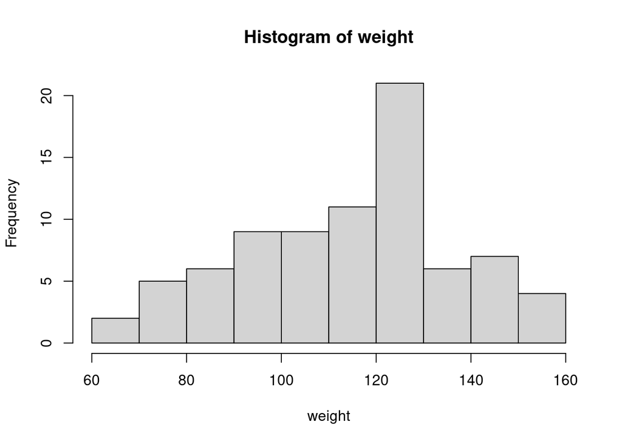

```r
# Set a seed number so you can always simulate the same values when you run this code
set.seed( 12345 )
# Simulate data
n  <- 80
mu <- 110
sd <- 20
# Get weight measurements for n = 80 panda specimens
weight <- rnorm( n = n, mean = mu, sd = sd )

hist(weight)
```

```r
optim(par = c(50,50), fn = lnL_norm, control = list(fnscale = -1), D = weight)
```

```
## $par
## [1] 114.09057  22.29862
##
## $value
## [1] -361.8789
##
## $counts
## function gradient
##       71       NA
##
## $convergence
## [1] 0
##
## $message
## NULL
```

#### Questions

1. Plot this normal distribution.
2. What are the values of parameters $\mu$ and standard deviation that maximize this likelihood function?